# Microreport_diabetes

Authors

Mireia Rivas Bermúdez - s263509

Lukas Beržinis - s263503

Amanda Espinas Novau - s263508

Marta Taboada Ramírez - s263518

Carla Ruedas - s251157

## Background

Diabetes mellitus remains a major global public health crisis with a growing burden across adult populations. The etiology of Type 2 diabetes mellitus (T2DM) involves a complex interplay between modifiable and non-modifiable risk factors. Excess body weight and body mass index (BMI) is a primary driver of systemic insulin resistance, chronic low-grade inflammation, and metabolic derangement (Yan et al., 2023).

Advancing age is currently being studied as a possible independent risk factor for the development of the disease. Characterized by progressive declines in pancreatic $\beta$-cell function, loss of skeletal muscle mass (sarcopenia), and reduced peripheral glucose clearance (Malandrino et al., 2024; Yan et al., 2023).

## Aim

This study aims to evaluate the interrelations between age and BMI in the development of diabetes, specifically testing for additive or multiplicative synergistic effects between both variables while investigating sex-specific risk trajectories.

To address these objectives, the study focuses on the following research questions:

1. **Synergistic Effects:** Is there a statistically significant interaction (additive or multiplicative) between age and BMI in predicting incident diabetes, indicating a synergistic effect between adiposity and advancing age?
2. **Sexual Dimorphism:** How does the joint impact of age and BMI manifest across biological sexes, and do males and females exhibit distinct risk trajectories over time?

## Loading libraries

```r
library("readr")
library("tidyverse")
library("ggplot2")
library("broom")
library("here")
library("ggrepel")
```

## Loading data:

```r
target_url <- "https://hbiostat.org/data/repo/diabetes.csv"
raw_data_file <- here("data/raw_data/diabetes.csv")

if (file.exists(raw_data_file)){
  diabetes_raw <- read_csv(raw_data_file)
} else {
  diabetes_raw <- read_csv(file = target_url)
  dir.create(path = dirname(raw_data_file), showWarnings = FALSE, recursive = TRUE)
  write_csv(x = diabetes_data, file = raw_data_file)
}
```

## Data Preparation

Before performing PCA, the available variables and their data types were inspected to identify suitable numerical variables for the analysis.

```r
names(diabetes_raw)
```

```
 [1] "id"       "chol"     "stab.glu" "hdl"      "ratio"    "glyhb"
 [7] "location" "age"      "gender"   "height"   "weight"   "frame"
[13] "bp.1s"    "bp.1d"    "bp.2s"    "bp.2d"    "waist"    "hip"
[19] "time.ppn"
```

```r
glimpse(diabetes_raw)
```

```
Rows: 403
Columns: 19
$ id       <dbl> 1000, 1001, 1002, 1003, 1005, 1008, 1011, 1015, 1016, 1022, 1…
$ chol     <dbl> 203, 165, 228, 78, 249, 248, 195, 227, 177, 263, 242, 215, 23…
$ stab.glu <dbl> 82, 97, 92, 93, 90, 94, 92, 75, 87, 89, 82, 128, 75, 79, 76, …
$ hdl      <dbl> 56, 24, 37, 12, 28, 69, 41, 44, 49, 40, 54, 34, 36, 46, 30, 4…
$ ratio    <dbl> 3.6, 6.9, 6.2, 6.5, 8.9, 3.6, 4.8, 5.2, 3.6, 6.6, 4.5, 6.3, 6…
$ glyhb    <dbl> 4.31, 4.44, 4.64, 4.63, 7.72, 4.81, 4.84, 3.94, 4.84, 5.78, 4…
$ location <chr> "Buckingham", "Buckingham", "Buckingham", "Buckingham", "Buck…
$ age      <dbl> 46, 29, 58, 67, 64, 34, 30, 37, 45, 55, 60, 38, 27, 40, 36, 3…
$ gender   <chr> "female", "female", "female", "male", "male", "male", "male",…
$ height   <dbl> 62, 64, 61, 67, 68, 71, 69, 59, 69, 63, 65, 58, 60, 59, 69, 6…
$ weight   <dbl> 121, 218, 256, 119, 183, 190, 191, 170, 166, 202, 156, 195, 1…
$ frame    <chr> "medium", "large", "large", "large", "medium", "large", "medi…
$ bp.1s    <dbl> 118, 112, 190, 110, 138, 132, 161, NA, 160, 108, 130, 102, 13…
$ bp.1d    <dbl> 59, 68, 92, 50, 80, 86, 112, NA, 80, 72, 90, 68, 80, NA, 66, …
$ bp.2s    <dbl> NA, NA, 185, NA, NA, NA, 161, NA, 128, NA, 130, NA, NA, NA, N…
$ bp.2d    <dbl> NA, NA, 92, NA, NA, NA, 112, NA, 86, NA, 90, NA, NA, NA, NA, …
$ waist    <dbl> 29, 46, 49, 33, 44, 36, 46, 34, 34, 45, 39, 42, 35, 37, 36, 3…
$ hip      <dbl> 38, 48, 57, 38, 41, 42, 49, 39, 40, 50, 45, 50, 41, 43, 40, 4…
$ time.ppn <dbl> 720, 360, 180, 480, 300, 195, 720, 1020, 300, 240, 300, 90, 7…
```

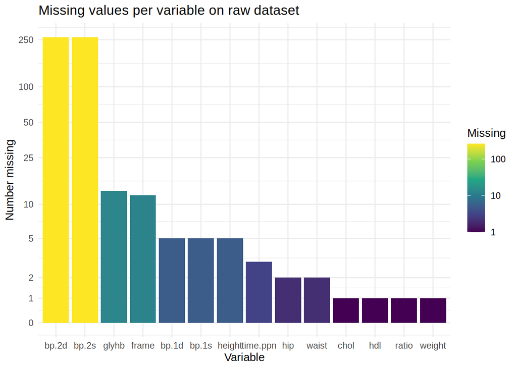

```r
variable_missingness <- diabetes_raw |>
  summarise(across(everything(), ~ sum(is.na(.x)))) |>
  pivot_longer(
    everything(), names_to = "variable", values_to = "n_missing"
  ) |>
  filter(n_missing > 0)

ggplot(
  variable_missingness,
  aes(
    x = fct_reorder(variable, n_missing, .desc = TRUE),
    y = n_missing, fill = n_missing)
  ) +
  geom_col() +
  scale_fill_viridis_c(trans = "log10") +
  scale_y_continuous(
    trans = scales::pseudo_log_trans(base = 10),
    breaks = c(0, 1, 2, 5, 10, 25, 50, 100, 250)
  ) +
  theme_minimal() +
  labs(
    title = "Missing values per variable on raw dataset",
    x = "Variable", y = "Number missing", fill = "Missing"
  )
```

The raw data consisted of 19 variables (including `id`) across 403 samples. 14 of those variables had some degree of missingness: `chol` , `hdl` , `ratio` and `weight` had missing values in just one sample, while `bp.2s` and `bp.2d` had 262 missing values each.

```r
# Filtering data

diabetes <- diabetes_raw |>
  filter(!(is.na(age))) |>
  filter(!(is.na(height))) |>
  filter(!(is.na(weight)))

nrow(diabetes)
```

```
[1] 397
```

After removing samples with missing height and weight values, required for calculating BMI, we were left with 397 samples for downstream data analysis.

## Data Analysis

### Search for synergetic effects:

We will first represent the data using a stacked bar chart to observe general trends. To do that we must first stratify our population based on age and BMI

```r
BMI_levels <- c("Underweight","Regular weight", "overweight","obese")
age_levels <- c("young","adult","mature","old")

# stratifying data
diabetes <- diabetes |>
  mutate(BMI = (weight/(height^2)) * 703) |>
  mutate(BMI_class = case_when(
    BMI < 18.5 ~ "Underweight",
    BMI >= 18.5 & BMI < 25.5 ~ "Regular weight",
    BMI >= 25.5 & BMI < 30 ~ "overweight",
    BMI >= 30 ~ "obese"
  )) |>
  mutate(age_group = factor(case_when(
    age < 25 ~ "young",
    age >= 25 & age < 50 ~ "adult",
    age >= 50 & age < 75 ~ "mature",
    age >= 75 ~ "old"
  ), levels = age_levels))

# Number of each group:
groups <- diabetes |>
  group_by(age_group, BMI_class) |>
  summarize(sum_individuals = n())
```

```
`summarise()` has regrouped the output.
ℹ Summaries were computed grouped by age_group and BMI_class.
ℹ Output is grouped by age_group.
ℹ Use `summarise(.groups = "drop_last")` to silence this message.
ℹ Use `summarise(.by = c(age_group, BMI_class))` for per-operation grouping
  (`?dplyr::dplyr_by`) instead.
```

```r
total <-  sum(groups$sum_individuals)

groups <- groups |>
  mutate(prop = sum_individuals/total)

diabetes <- ungroup(diabetes)

BMI_factor <- factor(diabetes$BMI_class, levels = BMI_levels)
age_factor <- factor(age_levels, levels = age_levels)
```

Now we can represent the data:

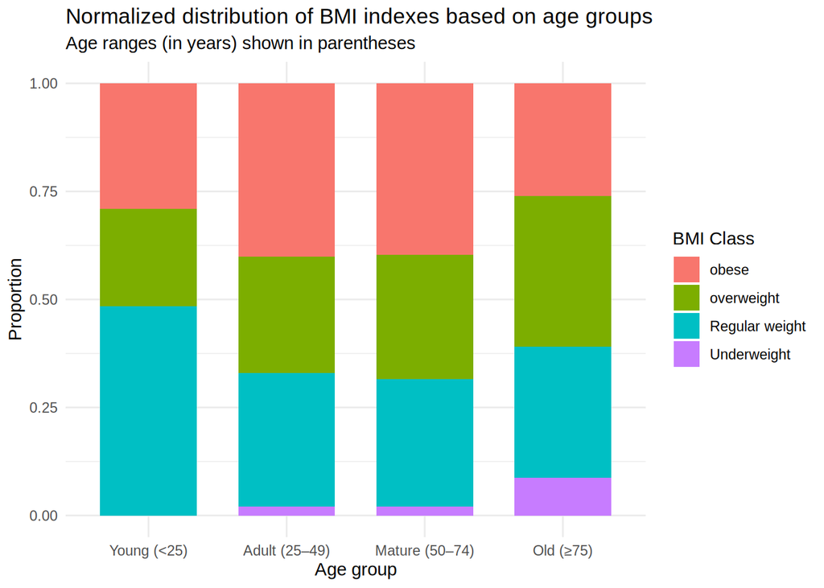

```r
groups_prop <- groups |>
  group_by(age_group) |>
  mutate(
    prop = sum_individuals / sum(sum_individuals)
  ) |>
  ungroup() |>
  mutate(
    age_group = fct_relabel(
      age_group,
      ~ paste(
        str_to_sentence(.x),
        recode_values(
          .x,
          "young" ~ "(<25)",
          "adult" ~ "(25–49)",
          "mature" ~ "(50–74)",
          "old" ~ "(≥75)"
        )
      )
    )
  )

ggplot(groups_prop, aes(x = age_group, y = prop, fill = BMI_class)) +
  geom_col(width = 0.7) +
  theme_minimal() +
  labs(
    title = "Normalized distribution of BMI indexes based on age groups",
    subtitle = "Age ranges (in years) shown in parentheses",
    x = "Age group",
    y = "Proportion",
    fill = "BMI Class"
  )
```

The obese proportion is lowest in the young group (29%) and highest in adults and mature adults (around 40% each), dropping again in the old group (26%), where overweight becomes the largest class instead (35%).

### Search for sexual dimorphism

To investigate the second research question, we tested whether the way age and BMI relate to diabetes differs between males and females.

Diabetes was defined as glycosylated hemoglobin (`glyhb`) $\geq$ 6.5%

```r
diabetes_sex <- diabetes |>
  filter(!is.na(glyhb), !is.na(gender)) |>
  mutate(diabetic = as.integer(glyhb >= 6.5))

# Number of individuals and prevalence by sex
diabetes_sex |>
  group_by(gender) |>
  summarize(n = n(), prevalence = mean(diabetic))
```

```
# A tibble: 2 × 3
  gender     n prevalence
  <chr>  <int>      <dbl>
1 female   223      0.157
2 male     161      0.174
```

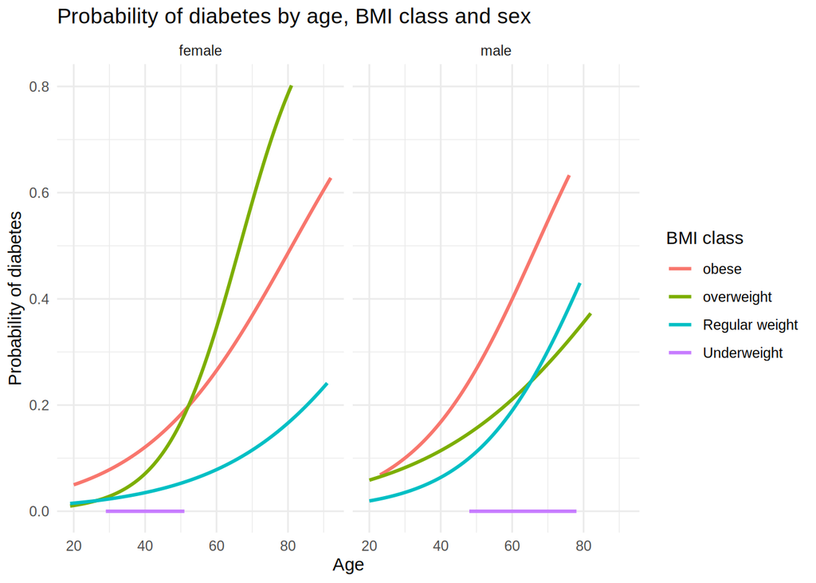

```r
ggplot(diabetes_sex, aes(x = age, y = diabetic, colour = BMI_class)) +
  geom_smooth(method = "glm", method.args = list(family = "binomial"), se = FALSE) +
  facet_wrap(~ gender) +
  labs(
    title = "Probability of diabetes by age, BMI class and sex",
    x = "Age",
    y = "Probability of diabetes",
    colour = "BMI class"
  ) +
  theme_minimal()
```

To test for differences between sexes, we fitted two logistic regression models: one without sex and one where sex interacts with age, BMI and their interaction. Comparing them with a likelihood ratio test tells us whether sex changes the effect of age and BMI.

```r
model_no_sex <- glm(diabetic ~ age * BMI, data = diabetes_sex, family = binomial)

tidy(model_no_sex)
```

```
# A tibble: 4 × 5
  term         estimate std.error statistic p.value
  <chr>           <dbl>     <dbl>     <dbl>   <dbl>
1 (Intercept) -5.68       2.43       -2.34   0.0192
2 age          0.0414     0.0438      0.946  0.344
3 BMI          0.0387     0.0783      0.494  0.621
4 age:BMI      0.000513   0.00144     0.355  0.723
```

Answering the first research question, the age × BMI interaction in the pooled model was not statistically significant (estimate = 0.0005, p = 0.72), so no synergistic effect between age and BMI was detected.

```r
model_sex <- glm(diabetic ~ age * BMI * gender, data = diabetes_sex, family = binomial)

anova(model_no_sex, model_sex, test = "Chisq")
```

```
Analysis of Deviance Table

Model 1: diabetic ~ age * BMI
Model 2: diabetic ~ age * BMI * gender
  Resid. Df Resid. Dev Df Deviance Pr(>Chi)
1       380     295.46
2       376     292.87  4   2.5926   0.6281
```

Finally, the age × BMI model was fitted separately in females and males to compare the effects within each sex.

```r
model_female <- glm(diabetic ~ age * BMI,
                    data = filter(diabetes_sex, gender == "female"),
                    family = binomial)

model_male <- glm(diabetic ~ age * BMI,
                  data = filter(diabetes_sex, gender == "male"),
                  family = binomial)

tidy(model_female)
```

```
# A tibble: 4 × 5
  term         estimate std.error statistic p.value
  <chr>           <dbl>     <dbl>     <dbl>   <dbl>
1 (Intercept) -7.16       3.16       -2.27   0.0233
2 age          0.0695     0.0555      1.25   0.211
3 BMI          0.0784     0.0964      0.813  0.416
4 age:BMI     -0.000326   0.00174    -0.188  0.851
```

```r
tidy(model_male)
```

```
# A tibble: 4 × 5
  term        estimate std.error statistic p.value
  <chr>          <dbl>     <dbl>     <dbl>   <dbl>
1 (Intercept) -2.79      4.39       -0.636   0.525
2 age         -0.0300    0.0844     -0.356   0.722
3 BMI         -0.0534    0.154      -0.346   0.730
4 age:BMI      0.00299   0.00301     0.993   0.321
```

### Principal Component Analysis

```r
pca_data <- diabetes |>
  select(
    gender,
    BMI_class,
    age,
    BMI,
    waist,
    hip,
    chol,
    stab.glu,
    hdl,
    glyhb,
    bp.1s,
    bp.1d
  ) |>
  drop_na()
```

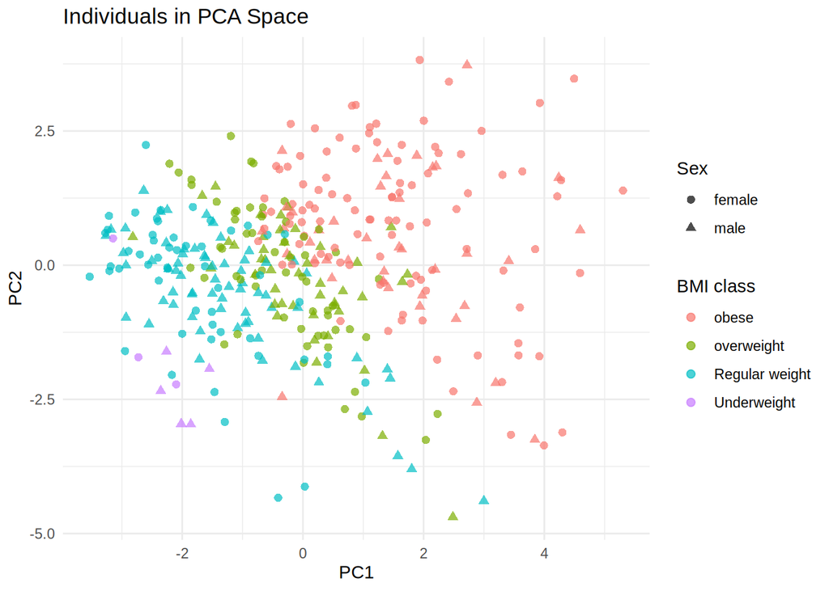

```r
pca_fit <- pca_data |>
  select(where(is.numeric)) |>
  prcomp(
    scale = TRUE
  )
pca_scores <- pca_fit |>
  augment(pca_data)

pca_scores |>
  ggplot(
    aes(
      x = .fittedPC1,
      y = .fittedPC2,
      colour = BMI_class,
      shape = gender
    )
  ) +
  geom_point(
    size = 2,
    alpha = 0.7
  ) +
  labs(
    title = "Individuals in PCA Space",
    x = "PC1",
    y = "PC2",
    colour = "BMI class",
    shape = "Sex"
  ) +
  theme_minimal()
```

PC1 separates individuals along a clear BMI gradient, from underweight to obese, while separation by sex is minor.

```r
pca_loadings <- pca_fit |>
  tidy(
    matrix = "rotation"
  )

pca_loadings
```

```
# A tibble: 100 × 3
   column    PC   value
   <chr>  <dbl>   <dbl>
 1 age        1  0.185
 2 age        2 -0.427
 3 age        3  0.0142
 4 age        4 -0.0400
 5 age        5  0.769
 6 age        6  0.0690
 7 age        7  0.394
 8 age        8 -0.0204
 9 age        9  0.168
10 age       10 -0.0371
# ℹ 90 more rows
```

```r
arrow_style <- arrow(
  angle = 20,
  ends = "first",
  type = "closed",
  length = grid::unit(8, "pt")
)
```

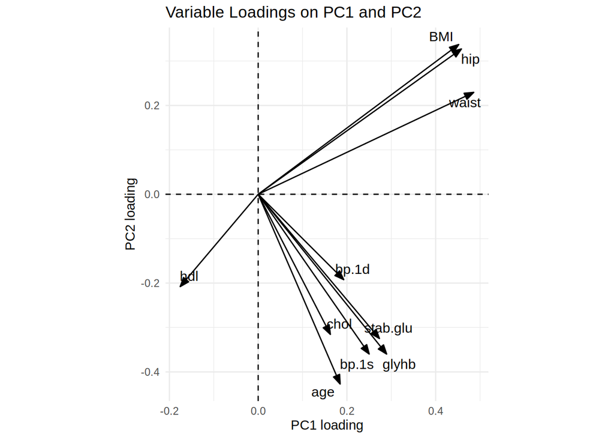

```r
pca_loadings |>
  filter(
    PC %in% c(1, 2)
  ) |>
  pivot_wider(
    names_from = PC,
    names_prefix = "PC",
    values_from = value
  ) |>
  ggplot(
    aes(
      x = PC1,
      y = PC2
    )
  ) +
  geom_hline(
    yintercept = 0,
    linetype = "dashed"
  ) +
  geom_vline(
    xintercept = 0,
    linetype = "dashed"
  ) +
  geom_segment(
    aes(
      xend = 0,
      yend = 0
    ),
    arrow = arrow_style
  ) +
  geom_text_repel(
    aes(
      label = column
    ),
    size = 4
  ) +
  coord_fixed() +
  labs(
    title = "Variable Loadings on PC1 and PC2",
    x = "PC1 loading",
    y = "PC2 loading"
  ) +
  theme_minimal()
```

PC1 is dominated by body-size measures (waist, hip, BMI), while PC2 contrasts age and glycemic/blood pressure measures against those same body-size measures.

### Variance Explained by the Principal Components

The proportion of total variance explained by each principal component was extracted to assess how much information is retained by the first components.

```r
pca_variance <- pca_fit |>
  tidy(
    matrix = "eigenvalues"
  )

pca_variance
```

```
# A tibble: 10 × 4
      PC std.dev percent cumulative
   <dbl>   <dbl>   <dbl>      <dbl>
 1     1   1.79   0.319       0.319
 2     2   1.43   0.204       0.523
 3     3   1.24   0.153       0.677
 4     4   1.00   0.100       0.777
 5     5   0.888  0.0788      0.856
 6     6   0.803  0.0644      0.920
 7     7   0.520  0.0271      0.947
 8     8   0.499  0.0249      0.972
 9     9   0.414  0.0171      0.989
10    10   0.326  0.0106      1
```

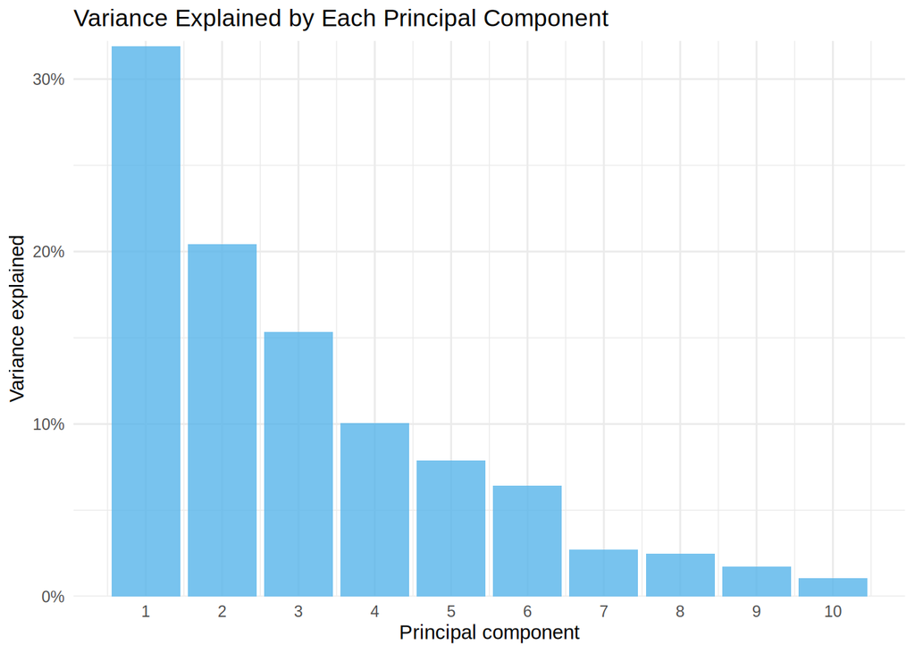

```r
pca_variance |>
  ggplot(
    aes(
      x = PC,
      y = percent
    )
  ) +
  geom_col(
    fill = "#56B4E9",
    alpha = 0.8
  ) +
  scale_x_continuous(
    breaks = 1:10
  ) +
  scale_y_continuous(
    labels = scales::percent_format(),
    expand = expansion(
      mult = c(0, 0.01)
    )
  ) +
  labs(
    title = "Variance Explained by Each Principal Component",
    x = "Principal component",
    y = "Variance explained"
  ) +
  theme_minimal()
```

PC1 explained 31.9% of the total variance, while PC2 explained 20.4%. Together, the first two principal components explained 52.3% of the total variance in the selected variables.

### Cumulative Variance Explained

The first two principal components explain 52.3% of the total variance. However, this means that almost half of the information is not represented in the first two components. To better understand how much information we keep when adding more components, we can look at the cumulative variance explained.

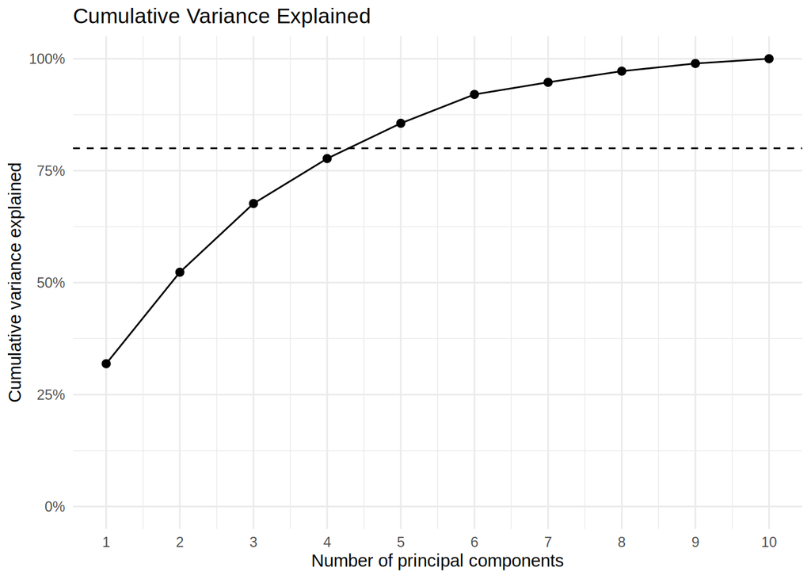

```r
pca_variance |>
  ggplot(aes(x = PC, y = cumulative)) +
  geom_line() +
  geom_point(size = 2) +
  geom_hline(
    yintercept = 0.8,
    linetype = "dashed"
  ) +
  scale_x_continuous(
    breaks = pca_variance$PC
  ) +
  scale_y_continuous(
    labels = scales::percent_format(),
    limits = c(0, 1)
  ) +
  labs(
    title = "Cumulative Variance Explained",
    x = "Number of principal components",
    y = "Cumulative variance explained"
  ) +
  theme_minimal()
```

This plot shows how the explained variance increases when more principal components are included. The dashed line marks 80% of the total variance, making it easier to see how many components are needed to reach this level. This helps us understand how much information can be retained while reducing the number of variables.

## Conclusion

**Synergistic effects:** The age × BMI interaction was not statistically significant in the pooled model (p = 0.72), so no evidence of a synergistic effect between age and BMI on diabetes risk was found.

The cumulative variance plot shows that the first four components explain around 77% of the total variance, while five components explain more than 80%. This means that the first two components are useful for visualizing the data, but they do not capture all its variability. Including more components allows us to retain more information from the original dataset.

## Bibliography:

Chen, Y., Zhang, X.-P., Yuan, J., Cai, B., Wang, X.-L., Wu, X.-L., Zhang, Y.-H., Zhang, X.-Y., Yin, T., Zhu, X.-H., Gu, Y.-J., Cui, S.-W., Lu, Z.-Q., & Li, X.-Y. (2018). Association of body mass index and age with incident diabetes in Chinese adults: a population-based cohort study. *BMJ Open*, *8*(9), e021768. https://doi.org/10.1136/bmjopen-2018-021768 Cited by: 305

Malandrino, N., Metter, E. J., Simonsick, E. M., Egan, J. M., Chia, C. W., Walston, J. D., Ferrucci, L., & Kalyani, R. R. (2024). Body Mass Index and Diabetes Incidence Across the Adult Lifespan: The Baltimore Longitudinal Study of Aging. *Journal of the Endocrine Society*, *8*(11), bvae156. https://doi.org/10.1210/jendso/bvae156 Cited by: 9

Wu, B., Chen, Y., Xu, H., Chen, Y., Dong, X., & Fu, C. (2023). Sex and age differences in the association between obesity and long-term changes with the risk of incident type 2 diabetes mellitus: the Rural Deqing Cohort Study. *Hepatobiliary Surgery and Nutrition*, *0*, 0–0. https://doi.org/10.21037/hbsn-24-417 Cited by: 2

Yan, Z., Cai, M., Han, X., Chen, Q., & Lu, H. (2023). The Interaction Between Age and Risk Factors for Diabetes and Prediabetes: A Community-Based Cross-Sectional Study. *Diabetes, Metabolic Syndrome and Obesity*, *16*, 85–93. https://doi.org/10.2147/dmso.s390857 Cited by: 211